# Analisis Perbandingan Kinerja Emiten Saham dan Pembelajaran Karakteristik Industri Sub-sektor Pulp&Paper dalam Basic Industry and Chemicals

## Analisis

#### Akan dilakukan analisis visualisasi perbandingan harga close pada tiga emiten sub-sektor pulp&paper untuk membandingkan kinerja ketiga emiten dan mempelajari karakteristik sub-sektor

[figure not shown]

```python
import pandas as pd
import matplotlib.pyplot as plt
from sklearn import preprocessing
import numpy as np
```

## Dataset 1

#### Data yang diimport adalah data harga saham dari emiten SWAT pada timeframe daily dalam rentang satu tahun (12 September 2018-12 September 2019)

#### Visualisasi dataset saham sangat berguna untuk membandingkan performa emiten pada industri yang sama

#### serta dibutuhkan analisis berbagai machine learning pada data saham untuk mendapatkan prediksi kemungkinan pergerakan harga

#### Sebelum dilakukan machine learning pada data, harus dilakukan visualisasi untuk mengecek kualitas data dan menentukan model machine learning yang sesuai

#### Sumber data adalah : https://finance.yahoo.com/quote/SWAT.JK/history?p=SWAT.JK

```python
df=pd.read_csv('data1.csv')
#Import dataframe dari CSV
```

```python
df.head()
#pengecekkan data yang telah di transfer
```

|  | Date | Open | High | Low | Close | Adj Close | Volume |
| --- | --- | --- | --- | --- | --- | --- | --- |
| 0 | 2018-09-12 | 136.0 | 138.0 | 134.0 | 134.0 | 134.0 | 3931400.0 |
| 1 | 2018-09-13 | 137.0 | 139.0 | 133.0 | 135.0 | 135.0 | 8710500.0 |
| 2 | 2018-09-14 | 135.0 | 136.0 | 133.0 | 133.0 | 133.0 | 7979300.0 |
| 3 | 2018-09-17 | 134.0 | 136.0 | 117.0 | 129.0 | 129.0 | 42721200.0 |
| 4 | 2018-09-18 | 129.0 | 133.0 | 125.0 | 126.0 | 126.0 | 8802000.0 |

```python
df.tail()
#pengecekkan jumlah data
```

|  | Date | Open | High | Low | Close | Adj Close | Volume |
| --- | --- | --- | --- | --- | --- | --- | --- |
| 257 | 2019-09-06 | 117.0 | 128.0 | 117.0 | 123.0 | 123.0 | 10828200.0 |
| 258 | 2019-09-09 | 123.0 | 129.0 | 123.0 | 124.0 | 124.0 | 9249100.0 |
| 259 | 2019-09-10 | 123.0 | 124.0 | 121.0 | 121.0 | 121.0 | 8335200.0 |
| 260 | 2019-09-11 | 121.0 | 123.0 | 119.0 | 119.0 | 119.0 | 8832300.0 |
| 261 | 2019-09-12 | 120.0 | 123.0 | 120.0 | 121.0 | 121.0 | 8811100.0 |

## Plotting dengan matplotlib

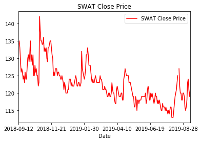

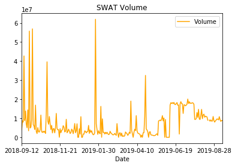

```python
ax = plt.gca()
df.plot(kind='line',x='Date',y='Close',color='red',ax=ax, title="SWAT Close Price")
#digunakan close price karena close merupakan harga yang disepakati pada akhir hari
df.plot(kind='line',x='Date',y='Volume', color='orange', title="SWAT Volume")
ax.legend(["SWAT Close Price"]);
```

## Dataset 2

#### Data yang diimport adalah data harga saham dari emiten FASW pada timeframe daily dalam rentang satu tahun (12 September 2018-12 September 2019)

#### FASW adalah emiten yang bergerak pada sub-sektor industri yang sama dengan SWAT

#### Sumber data adalah https://finance.yahoo.com/quote/FASW.JK/history?p=FASW.JK

```python
df1=pd.read_csv('data2.csv')
```

```python
df1.head()
```

|  | Date | Open | High | Low | Close | Adj Close | Volume |
| --- | --- | --- | --- | --- | --- | --- | --- |
| 0 | 2018-09-12 | 7575.0 | 7800.0 | 7575.0 | 7650.0 | 7337.571289 | 1030200 |
| 1 | 2018-09-13 | 7650.0 | 7900.0 | 7650.0 | 7825.0 | 7505.424316 | 1109600 |
| 2 | 2018-09-14 | 7825.0 | 8150.0 | 7825.0 | 8100.0 | 7769.192871 | 1069400 |
| 3 | 2018-09-17 | 8075.0 | 8075.0 | 7800.0 | 7850.0 | 7529.403320 | 840200 |
| 4 | 2018-09-18 | 7850.0 | 7950.0 | 7750.0 | 7850.0 | 7529.403320 | 1038600 |

```python
df1.tail()
```

|  | Date | Open | High | Low | Close | Adj Close | Volume |
| --- | --- | --- | --- | --- | --- | --- | --- |
| 257 | 2019-09-06 | 7800.0 | 7850.0 | 7800.0 | 7800.0 | 7800.0 | 20100 |
| 258 | 2019-09-09 | 7900.0 | 7900.0 | 7800.0 | 7800.0 | 7800.0 | 3500 |
| 259 | 2019-09-10 | 7800.0 | 7800.0 | 7800.0 | 7800.0 | 7800.0 | 22300 |
| 260 | 2019-09-11 | 7900.0 | 7900.0 | 7800.0 | 7800.0 | 7800.0 | 10700 |
| 261 | 2019-09-12 | 7800.0 | 7800.0 | 7800.0 | 7800.0 | 7800.0 | 13500 |

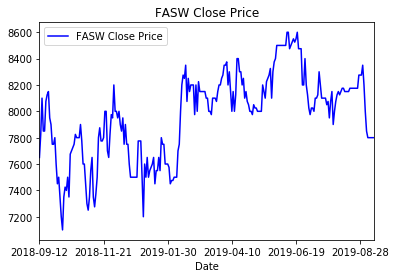

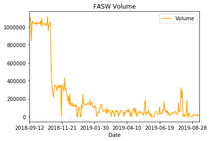

```python
ax = plt.gca()
df1.plot(kind='line',x='Date',y='Close',color='blue',ax=ax, title="FASW Close Price")
#digunakan close price karena close merupakan harga yang disepakati pada akhir hari
df1.plot(kind='line',x='Date',y='Volume', color='orange',title="FASW Volume")
ax.legend(["FASW Close Price"]);
```

## Dataset 3

#### Data yang diimport adalah data harga saham dari emiten SPMA pada timeframe daily dalam rentang satu tahun (12 September 2018-12 September 2019)

#### SPMA adalah emiten yang bergerak pada sub-sektor industri yang sama dengan SWAT

#### Sumber data adalah https://finance.yahoo.com/quote/SPMA.JK/history?p=SPMA.JK

```python
df2=pd.read_csv('data3.csv')
#Import dataframe dari CSV
```

```python
df2.head()
```

|  | Date | Open | High | Low | Close | Adj Close | Volume |
| --- | --- | --- | --- | --- | --- | --- | --- |
| 0 | 2018-09-12 | 234.0 | 240.0 | 234.0 | 240.0 | 240.0 | 13800 |
| 1 | 2018-09-13 | 242.0 | 242.0 | 236.0 | 236.0 | 236.0 | 16200 |
| 2 | 2018-09-14 | 238.0 | 240.0 | 238.0 | 240.0 | 240.0 | 19100 |
| 3 | 2018-09-17 | 240.0 | 240.0 | 240.0 | 240.0 | 240.0 | 0 |
| 4 | 2018-09-18 | 246.0 | 246.0 | 244.0 | 244.0 | 244.0 | 300 |

```python
df2.tail()
```

|  | Date | Open | High | Low | Close | Adj Close | Volume |
| --- | --- | --- | --- | --- | --- | --- | --- |
| 257 | 2019-09-06 | 338.0 | 338.0 | 334.0 | 338.0 | 338.0 | 50700 |
| 258 | 2019-09-09 | 342.0 | 348.0 | 342.0 | 348.0 | 348.0 | 296100 |
| 259 | 2019-09-10 | 350.0 | 358.0 | 344.0 | 350.0 | 350.0 | 437600 |
| 260 | 2019-09-11 | 352.0 | 358.0 | 348.0 | 350.0 | 350.0 | 426600 |
| 261 | 2019-09-12 | 354.0 | 354.0 | 350.0 | 354.0 | 354.0 | 448400 |

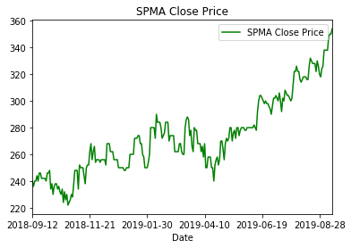

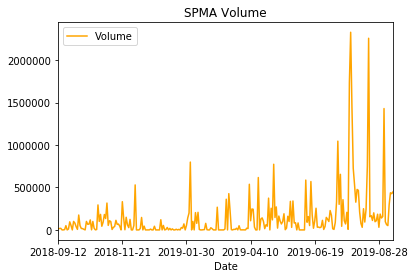

```python
ax=plt.gca()
df2.plot(kind='line',x='Date',y='Close',color='green',ax=ax, title="SPMA Close Price")
#digunakan close price karena close merupakan harga yang disepakati pada akhir hari
df2.plot(kind='line',x='Date',y='Volume', color='orange', title="SPMA Volume")
ax.legend(["SPMA Close Price"]);
```

## Komparasi Emiten

#### Untuk perbandingan, dilakukan normalisasi data tiap emiten terlebih dahulu agar dapat di plot dalam satu grafik yang sama

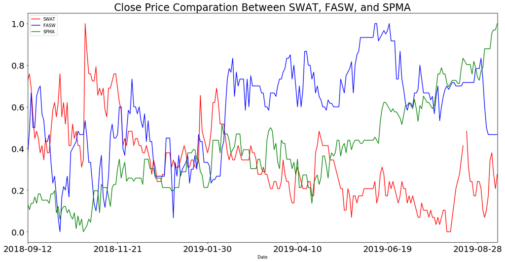

```python
x = df.loc[:,'Close'].values.reshape(-1,1) #returns a numpy array
min_max_scaler = preprocessing.MinMaxScaler()
x_scaled = min_max_scaler.fit_transform(x)
df['Normalized Close'] = x_scaled

x = df1.loc[:,'Close'].values.reshape(-1,1) #returns a numpy array
x_scaled = min_max_scaler.fit_transform(x)
df1['Normalized Close'] = x_scaled

x = df2.loc[:,'Close'].values.reshape(-1,1) #returns a numpy array
x_scaled = min_max_scaler.fit_transform(x)
df2['Normalized Close'] = x_scaled

ax= plt.gca()
df.plot(kind='line',x='Date',y='Normalized Close',color='red',ax=ax, fontsize= 20, figsize=(20, 10))
df1.plot(kind='line',x='Date',y='Normalized Close',color='blue',ax=ax)
df2.plot(kind='line',x='Date',y='Normalized Close',color='green',ax=ax)
ax.legend(["SWAT", "FASW","SPMA"])
ax.set_title("Close Price Comparation Between SWAT, FASW, and SPMA", fontdict={'fontsize': 24, 'fontweight': 'medium'})
# digunakan close price karena close merupakan harga yang disepakati pada akhir hari
```

## Permasalahan

#### Terlihat bahwa grafik sulit sekali dilihat karena data mentah dimasukkan secara langsung tanpa diolah sesuai kebutuhan, karena kebutuhan hanya berupa perbandingan trend, digunakan moving average. Simple Moving average period 20 hari (SMA_20) dibentuk untuk melakukan smoothing pada grafik, period 20 hari digunakan karena data saham memiliki pola mingguan selama 20 hari dalam sebulan

```python
def averageClose20(i,df):
    x=0
    for i in range (i,i+19):
        x=x+df.loc[i,'Close']
    x=x/20
    return x
for i in range(0,df.shape[0]-20):
    df.loc[df.index[i+20],'SMA_20'] = averageClose20(i,df)
for i in range(0,df.shape[0]-20):
    df1.loc[df.index[i+20],'SMA_20'] = averageClose20(i,df1)
for i in range(0,df.shape[0]-20):
    df2.loc[df.index[i+20],'SMA_20'] = averageClose20(i,df2)
```

## Normalisasi Simple Moving Average

#### Setelah menggunakan SMA_20, SMA_20 masih menggunakan harga yang belum ternormalisasi, maka harus dinormalisasi untuk perbandingan antar emiten

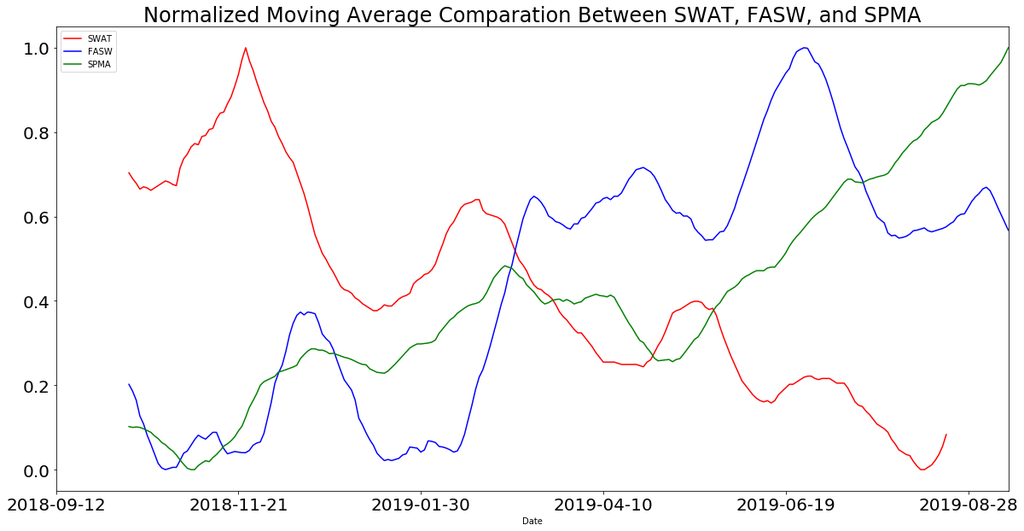

```python
x = df.loc[:,'SMA_20'].values.reshape(-1,1) #returns a numpy array
min_max_scaler = preprocessing.MinMaxScaler()
x_scaled = min_max_scaler.fit_transform(x)
df['Normalized SMA_20'] = x_scaled

x = df1.loc[:,'SMA_20'].values.reshape(-1,1) #returns a numpy array
x_scaled = min_max_scaler.fit_transform(x)
df1['Normalized SMA_20'] = x_scaled

x = df2.loc[:,'SMA_20'].values.reshape(-1,1) #returns a numpy array
x_scaled = min_max_scaler.fit_transform(x)
df2['Normalized SMA_20'] = x_scaled

ax= plt.gca()
df.plot(kind='line',x='Date',y='Normalized SMA_20',color='red',ax=ax, fontsize= 20,figsize=(20, 10))
df1.plot(kind='line',x='Date',y='Normalized SMA_20',color='blue',ax=ax)
df2.plot(kind='line',x='Date',y='Normalized SMA_20',color='green',ax=ax)
ax.legend(["SWAT", "FASW","SPMA"])
ax.set_title("Normalized Moving Average Comparation Between SWAT, FASW, and SPMA", fontdict={'fontsize': 24, 'fontweight': 'medium'})
```

## 3D Plot

#### Plotting dalam 3D untuk mempermudah perbandingan dan melihat lebih detail pergerakan

```python
import plotly.graph_objects as go
```

```python
for i in range(0,df.shape[0]-1):
#     df.loc[df.index[i],'Day'] = int(df.loc[i,'Date'][8:12])
#     df.loc[df.index[i],'Month'] = int(df.loc[i,'Date'][5:7])
#     df.loc[df.index[i],'Gradient'] = (df.loc[i+1,'Close']-df.loc[i,'Close'])/2
    df.loc[df.index[i],'Label'] = "SWAT"
    df1.loc[df1.index[i],'Label'] = "FASW"
    df2.loc[df2.index[i],'Label'] = "SPMA"
    newdf=pd.concat([df,df1,df2])
```

```python
fig = go.Figure(data=[go.Scatter3d(
    x=newdf['Date'],
    y=newdf['Label'],
    z=newdf['Normalized SMA_20'],
    mode='markers',
    marker=dict(
        size=12,
        color=newdf['Normalized SMA_20'], # set color to an array/list of desired values
        colorscale='Viridis',   # choose a colorscale
        opacity=0.5,
    )
)])

# tight layout
fig.update_layout(margin=dict(l=0, r=0, b=0, t=0))
fig.show()
```

[interactive chart not shown]

## Kesimpulan

#### Perbedaan performa yang besar pada Mei-Agustus

#### Berdasarkan hal tersebut, dibutuhkan analisis lebih lanjut mengenai karakteristik industri secara mendetail karena terlihat beberapa pola pergerakan harga yang mirip pada beberapa rentang periode tertentu untuk mencari kemungkinan karakteristik periodik penggerak harga dan implikasinya (gradien +/-), merupakan kemungkinan pengembangan kedepannya